# Visualizing Asteroids & Meteorites Impact Data

Filis Coba, Kalsoom Malik, Beka Hajimohammed

In this project, we will examine two types of NASA data (meteorites and astroids) taken from the following site: https://www.kaggle.com/nasa/datasets. We analyze NASA asteroid and meteorite data to visualize where impacts have occurred on Earth, and if more will occur in the future.

```python
#Importing the dependecies
#!conda install --yes basemap
#!conda update --yes pandas
from mpl_toolkits.basemap import Basemap
import matplotlib.pyplot as plt
import pandas as pd
import numpy as np
%matplotlib inline
import matplotlib
matplotlib.rcParams.update({'font.size': 18})
```

# Meteorite Data

The first data consists of meteorites which have struck Earth. We used a csv file from https://www.kaggle.com/nasa/meteorite-landings and uploaded the csv file into jupyter notebook in order to construct a dataframe useful for plotting.

A meteorite is a piece of iron, stone, or stony-iron composite that has fallen to Earth from outer space.

```python
# Loading the file
file = "meteorite-landings.csv"

# Reading the meteor csv data file
meteor = pd.read_csv(file)


# Displaying the data table for preview
meteor.head(5)
```

|  | name | id | nametype | recclass | mass | fall | year | reclat | reclong | GeoLocation |
| --- | --- | --- | --- | --- | --- | --- | --- | --- | --- | --- |
| 0 | Aachen | 1 | Valid | L5 | 21.0 | Fell | 1880.0 | 50.77500 | 6.08333 | (50.775000, 6.083330) |
| 1 | Aarhus | 2 | Valid | H6 | 720.0 | Fell | 1951.0 | 56.18333 | 10.23333 | (56.183330, 10.233330) |
| 2 | Abee | 6 | Valid | EH4 | 107000.0 | Fell | 1952.0 | 54.21667 | -113.00000 | (54.216670, -113.000000) |
| 3 | Acapulco | 10 | Valid | Acapulcoite | 1914.0 | Fell | 1976.0 | 16.88333 | -99.90000 | (16.883330, -99.900000) |
| 4 | Achiras | 370 | Valid | L6 | 780.0 | Fell | 1902.0 | -33.16667 | -64.95000 | (-33.166670, -64.950000) |

```python
meteor = meteor.rename(columns ={"recclass": "type", "fall": "discovery", "nametype": "appearance", "reclat": "lat", "reclong": "long", "GeoLocation": "coordinates"})

meteor.head()
```

|  | name | id | appearance | type | mass | discovery | year | lat | long | coordinates |
| --- | --- | --- | --- | --- | --- | --- | --- | --- | --- | --- |
| 0 | Aachen | 1 | Valid | L5 | 21.0 | Fell | 1880.0 | 50.77500 | 6.08333 | (50.775000, 6.083330) |
| 1 | Aarhus | 2 | Valid | H6 | 720.0 | Fell | 1951.0 | 56.18333 | 10.23333 | (56.183330, 10.233330) |
| 2 | Abee | 6 | Valid | EH4 | 107000.0 | Fell | 1952.0 | 54.21667 | -113.00000 | (54.216670, -113.000000) |
| 3 | Acapulco | 10 | Valid | Acapulcoite | 1914.0 | Fell | 1976.0 | 16.88333 | -99.90000 | (16.883330, -99.900000) |
| 4 | Achiras | 370 | Valid | L6 | 780.0 | Fell | 1902.0 | -33.16667 | -64.95000 | (-33.166670, -64.950000) |

```python
#Dropping some unecessary columns
meteor = meteor.drop(columns=["id", "coordinates"])
meteor.head()
```

|  | name | appearance | type | mass | discovery | year | lat | long |
| --- | --- | --- | --- | --- | --- | --- | --- | --- |
| 0 | Aachen | Valid | L5 | 21.0 | Fell | 1880.0 | 50.77500 | 6.08333 |
| 1 | Aarhus | Valid | H6 | 720.0 | Fell | 1951.0 | 56.18333 | 10.23333 |
| 2 | Abee | Valid | EH4 | 107000.0 | Fell | 1952.0 | 54.21667 | -113.00000 |
| 3 | Acapulco | Valid | Acapulcoite | 1914.0 | Fell | 1976.0 | 16.88333 | -99.90000 |
| 4 | Achiras | Valid | L6 | 780.0 | Fell | 1902.0 | -33.16667 | -64.95000 |

```python
meteor_count = meteor["year"].value_counts()
meteor_count.head()
```

```
2003.0    3323
1979.0    3046
1998.0    2697
2006.0    2456
1988.0    2296
Name: year, dtype: int64
```

```python
# Remove the rows with missing data
clean_meteor_df = meteor.dropna(how="any")
clean_meteor_df.count()
```

```
name          38116
appearance    38116
type          38116
mass          38116
discovery     38116
year          38116
lat           38116
long          38116
dtype: int64
```

```python
clean_meteor_df.head()
```

|  | name | appearance | type | mass | discovery | year | lat | long |
| --- | --- | --- | --- | --- | --- | --- | --- | --- |
| 0 | Aachen | Valid | L5 | 21.0 | Fell | 1880.0 | 50.77500 | 6.08333 |
| 1 | Aarhus | Valid | H6 | 720.0 | Fell | 1951.0 | 56.18333 | 10.23333 |
| 2 | Abee | Valid | EH4 | 107000.0 | Fell | 1952.0 | 54.21667 | -113.00000 |
| 3 | Acapulco | Valid | Acapulcoite | 1914.0 | Fell | 1976.0 | 16.88333 | -99.90000 |
| 4 | Achiras | Valid | L6 | 780.0 | Fell | 1902.0 | -33.16667 | -64.95000 |

```python
n_types = meteor['type'].unique().size
print(f'There are {n_types} unique meteor types.')
```

```
There are 466 unique meteor types.
```

```python
# Using GroupBy in order to separate the data into fields according to "state" values# Using
grouped_meteor_df = meteor.groupby(['year'])

# In order to be visualized, a data function must be used...
#grouped_meteor_df.head(5)
```

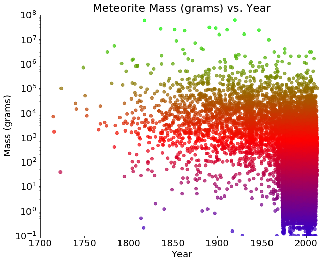

```python
x = meteor['year']
y = meteor['mass']
fig = plt.figure(figsize=(10,8))

plt.scatter(x, y, c=np.log10(y), cmap=plt.cm.brg, alpha=0.7)
plt.ylim([0.1,1e8])
plt.xlim([1700,2020])
plt.yscale('log')

plt.xlabel("Year")
plt.ylabel("Mass (grams)")
plt.title("Meteorite Mass (grams) vs. Year")
```

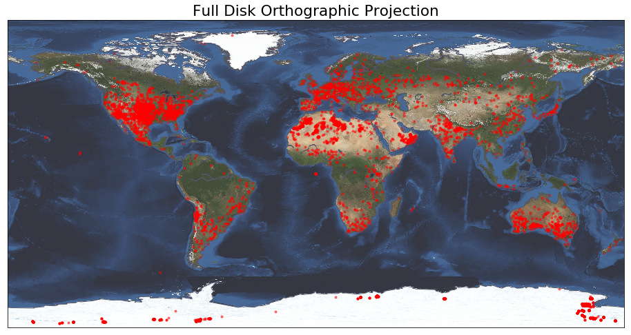

```python
# lon_0, lat_0 are the center point of the projection.
# resolution = 'l' means use low resolution coastlines.
fig = plt.figure(figsize=(16,11))
# m = Basemap(projection='ortho',lon_0=-105,lat_0=40,resolution='l')
m = Basemap()
m.bluemarble(alpha=0.8)
m.drawcoastlines(color="#555566", linewidth=1)
plt.scatter(meteor['long'], meteor['lat'], c='red', marker='.', alpha=0.5)
# m.drawcoastlines()
# m.fillcontinents(color='coral',lake_color='aqua')
# #draw parallels and meridians.
# m.drawparallels(np.arange(-90.,120.,30.))
# m.drawmeridians(np.arange(0.,420.,60.))
# m.drawmapboundary(fill_color='aqua')
plt.title("Full Disk Orthographic Projection")
```

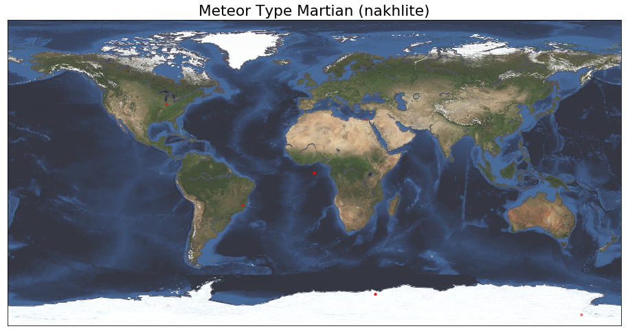

```python
# Look at one specific type
meteor_type = "Martian (nakhlite)"
L5 = meteor.loc[meteor['type'] == meteor_type]
# lon_0, lat_0 are the center point of the projection.
# resolution = 'l' means use low resolution coastlines.
fig = plt.figure(figsize=(16,11))
# m = Basemap(projection='ortho',lon_0=-105,lat_0=40,resolution='l')
m = Basemap()
m.bluemarble(alpha=0.8)
m.drawcoastlines(color="#555566", linewidth=1)
plt.scatter(L5['long'], L5['lat'], c='red', marker='.', alpha=0.5)
# m.drawcoastlines()
# m.fillcontinents(color='coral',lake_color='aqua')
# #draw parallels and meridians.
# m.drawparallels(np.arange(-90.,120.,30.))
# m.drawmeridians(np.arange(0.,420.,60.))
# m.drawmapboundary(fill_color='aqua')
plt.title(f"Meteor Type {meteor_type}")
```

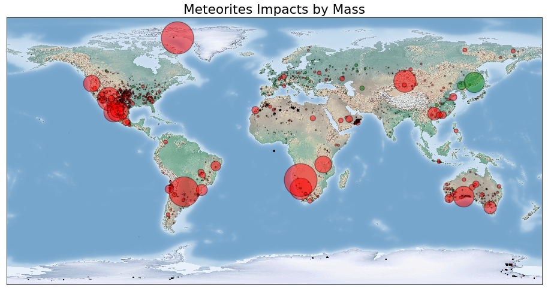

```python
def get_discovery_color(discovery):
    if discovery == 'Fell':
        return 'Green'
    elif discovery == 'Found':
        return 'Red'
    else:
        return 'Gold'

lat = clean_meteor_df['lat'].values
lon = clean_meteor_df['long'].values
mass = clean_meteor_df['mass'].values

discovery_type_list = clean_meteor_df['discovery']
discovery_color_list = [get_discovery_color(discovery_type) for discovery_type in discovery_type_list]

fig = plt.figure(figsize=(16,11))
m = Basemap()
m.shadedrelief()

m.scatter(lon, lat, #latlon=True,
          c=discovery_color_list, s=mass/20000,
          alpha=0.5, marker="o", edgecolors="black")

plt.title("Meteorites Impacts by Mass")
#plt.savefig("../meteorites_impact_by_mass.png")
```

# Asteroid Data

Asteroids are rocky worlds revolving around the sun that are too small to be called planets.

```python
# Loading the file
file = "impacts.csv"

# Reading the meteor csv data file
asteroid_impacts = pd.read_csv(file)


# Displaying the data table for preview
asteroid_impacts.head(10)
```

|  | Object Name | Period Start | Period End | Possible Impacts | Cumulative Impact Probability | Asteroid Velocity | Asteroid Magnitude | Asteroid Diameter (km) | Cumulative Palermo Scale | Maximum Palermo Scale | Maximum Torino Scale |
| --- | --- | --- | --- | --- | --- | --- | --- | --- | --- | --- | --- |
| 0 | 2006 WP1 | 2017 | 2017 | 1 | 5.200000e-09 | 17.77 | 28.3 | 0.007 | -8.31 | -8.31 | 0 |
| 1 | 2013 YB | 2017 | 2046 | 23 | 7.600000e-05 | 8.98 | 31.4 | 0.002 | -6.60 | -6.96 | 0 |
| 2 | 2008 US | 2017 | 2062 | 30 | 1.600000e-05 | 18.33 | 31.4 | 0.002 | -6.48 | -6.87 | 0 |
| 3 | 2010 VR139 | 2017 | 2076 | 24 | 2.000000e-07 | 4.99 | 26.7 | 0.016 | -6.83 | -6.95 | 0 |
| 4 | 2015 ME131 | 2017 | 2096 | 85 | 2.300000e-08 | 19.46 | 19.2 | 0.497 | -3.85 | -4.30 | 0 |
| 5 | 2010 XB73 | 2017 | 2110 | 55 | 2.800000e-07 | 5.98 | 22.5 | 0.110 | -5.03 | -5.51 | 0 |
| 6 | 2005 TM173 | 2017 | 2111 | 123 | 9.000000e-07 | 8.79 | 24.1 | 0.052 | -5.41 | -6.42 | 0 |
| 7 | 2006 SF281 | 2017 | 2111 | 514 | 1.900000e-06 | 4.49 | 26.2 | 0.020 | -5.91 | -7.58 | 0 |
| 8 | 2010 VP139 | 2017 | 2112 | 350 | 1.800000e-05 | 2.04 | 28.5 | 0.007 | -6.51 | -7.54 | 0 |
| 9 | 2014 HR197 | 2017 | 2112 | 187 | 7.900000e-08 | 17.02 | 26.9 | 0.014 | -7.18 | -7.97 | 0 |

**Period Start** = Tracking period in years  
**Possible Impacts** = Number of ways it can get close to Earth.  
**Cumulative Impact Probability** = Probability of hitting Earth during the entire period  
**Asteroid Velocity** = km / s  
**Asteroid Magnitude** = brightness of asteroid  
**Cumulative Palermo Scale** = Positive is high risk  
**Maximum Torino Scale** = 0 = no risk; 2-4 = some; $>$5 = High Risk

```python
asteroid = asteroid_impacts.rename(columns ={"Object Name": "Asteroid_Name"})
#asteroid.head()
```

```python
#Dropping some unecessary columns #Droppin
asteroids = asteroid.drop(columns = ["Maximum Torino Scale", "Asteroid Magnitude"])
#asteroids
```

The following plot is a histogram which bins the data and counts how many asteroids are in each bin. The x-axis is the cumulative impact probability as a percentage. This means the overall probability that the asteroid will strike Earth. The y-axis is the number of asteroids which have that probability of hitting Earth.

The danger zone corresponds to the percentage which is worrisome for a potential collision. From the plot, we can conclude that there is a low percentage of asteroids striking Earth.

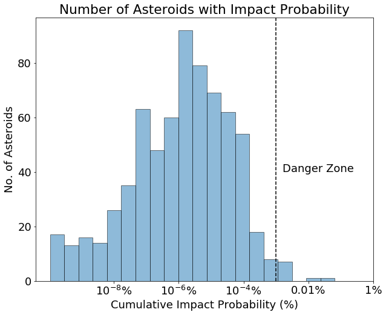

```python
fig = plt.figure(figsize=(10,8))

x = asteroids['Cumulative Impact Probability']
_ = plt.hist(np.log10(x), bins=20, edgecolor='black', alpha=0.5)
plt.axvline(-3, linestyle='--', color='black')
plt.xticks([-8,-6,-4,-2,0],[r'10$^{-8}$%', '10$^{-6}$%','10$^{-4}$%', '0.01%', '1%'])
plt.xlabel("Cumulative Impact Probability (%)")
plt.ylabel("No. of Asteroids")
plt.text(-2.8, 40,"Danger Zone")
plt.title("Number of Asteroids with Impact Probability")
```

This scatter plot shows the probability of impacts from asteroids based on their size.

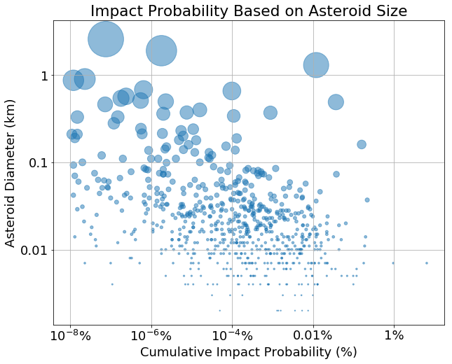

```python
x = np.log10(asteroids["Cumulative Impact Probability"]*100)
y_ = asteroids["Asteroid Diameter (km)"]
y = np.log10(y_)

fig = plt.figure(figsize=(10,8))
plt.scatter(x, y, s=y_*1000, alpha=0.5)
plt.xticks([-8,-6,-4,-2,0],[r'10$^{-8}$%', '10$^{-6}$%','10$^{-4}$%', '0.01%', '1%'])
plt.yticks([-2,-1,0],["0.01","0.1","1"])
plt.xlabel("Cumulative Impact Probability (%)")
plt.ylabel("Asteroid Diameter (km)")
plt.title("Impact Probability Based on Asteroid Size")
plt.grid()
plt.show()
```

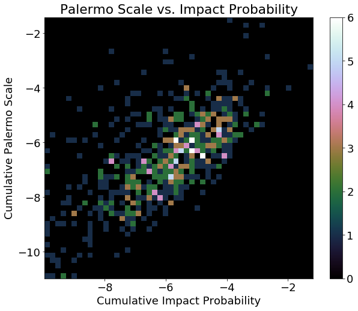

```python
fig = plt.figure(figsize=(10,8))
# ax = fig.add_subplot(111)
x = np.log10(asteroids['Cumulative Impact Probability'])
y = asteroids['Cumulative Palermo Scale']
_ = plt.hist2d(x,y, bins=50, figure=fig, cmap=plt.cm.cubehelix)
plt.colorbar()
plt.xlabel('Cumulative Impact Probability')
plt.ylabel('Cumulative Palermo Scale')
plt.title("Palermo Scale vs. Impact Probability")
```

This 2D density plot above says that there are x-number of asteroids for each combination of impact probability and Palermo scale, where x refers to the color bar value.

The positive slope shows that the higher the impact probability, the higher the risk of damage.

Palermo Scale  
-2 = normal  
$n>0$ = high risk of impact

How we made the plot:  
https://python-graph-gallery.com/85-density-plot-with-matplotlib/

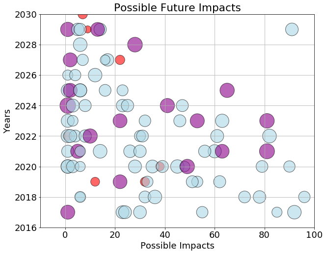

```python
def impact_score(impact):
    if impact < -8:
        return 'darkmagenta'
    elif impact < -4:
        return 'LightBlue'
    else:
        return 'red'

def asteroid_scale(scale):
    return (scale) * -100;


x = asteroids['Possible Impacts']
y = asteroids['Period Start']
z = asteroids['Maximum Palermo Scale']

asteroids_list = asteroids['Maximum Palermo Scale']
asteroids_list_colors = [impact_score(impact) for impact in asteroids_list]

asteroids_scale_list= [asteroid_scale(scale) for scale in asteroids_list]

fig = plt.figure(figsize=(10,8))
plt.ylim(2016,2030)
plt.xlim(-10,100)
plt.scatter(x, y, s=asteroids_scale_list , c=asteroids_list_colors, alpha=0.6, marker="o", edgecolors="black")

plt.title("Possible Future Impacts")
plt.xlabel("Possible Impacts")
plt.ylabel("Years")
plt.grid(True)

# plt.savefig("../possible_impacts_asteroids.png")
plt.show()
```

The plot above shows the number of ways the asteroids in our data can get close to Earth within the tracking period.

Dark Magenta shows least possibility to enter earth in that year and red marker shows higher chance than other two.